# 須山さんのベイズ本

2018-01-14

# Chapter 3

各種の分布に対する共役事前分布を用いた事前分布の更新について。

### ベルヌーイ分布

ベルヌーイ分布のパラメータ$p$の事前分布としてベータ分布が用いられる。データを観測した後の事後分布は、ベータ分布のパラメータ$a$と$b$それぞれに成功回数および（試行回数 - 成功回数）が加算される。

#### 事前分布

純粋なベイズ推論では事前分布はデータから得ることはせず、ドメイン知識を活用して天下り的に決定される。ベータ分布では$a$と$b$それぞれに1を指定すると、(0, 1)の範囲で一様となる。

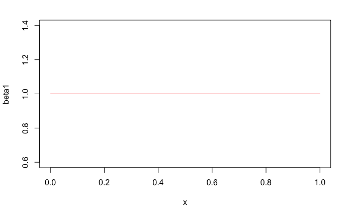

#### データの観測

真のパラメータが$p = 0.7$であるベルヌーイ分布から以下のように20個のデータを観測する。

```r
trial1 <- sample(x = c(1, 0), size = N1, replace = TRUE, prob = c(p, q))
```

[output not shown]

#### 事後分布

データの観測結果によって事前分布を更新する。 前述の通りベータ分布ではパラメータ$a$と$b$それぞれに成功回数と（試行回数 - 成功回数）が加算される。事前分布との比較を行う。

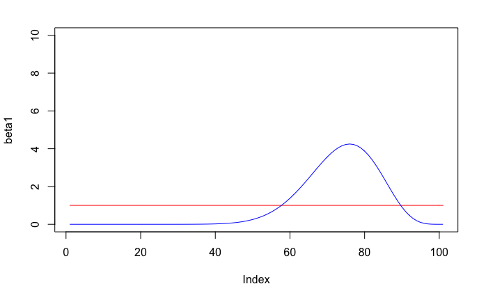

$p$の期待値が真の値に近づく。

```r
mean(rbeta(10000, a1, b1))
```

```
[1] 0.5051257
```

```r
mean(rbeta(10000, a2, b2))
```

```
[1] 0.7262871
```

##### さらにデータ追加

同じ分布からさらにデータを観測する。

```r
N2 <- 300
trial2 <- sample(x = c(1, 0), size = N2, replace = TRUE, prob = c(p, q))
```

##### 事後分布

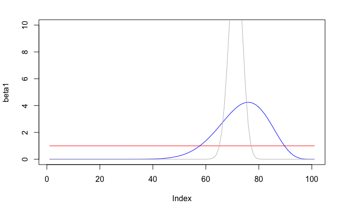

```r
mean(rbeta(10000, a1, b1))
```

```
[1] 0.4959105
```

```r
mean(rbeta(10000, a2, b2))
```

```
[1] 0.7264845
```

```r
mean(rbeta(10000, a3, b3))
```

```
[1] 0.7019852
```

#### おまけ

$a$と$b$の比を同じにしておくと、平均は同じでバラつきが異なる分布となる。このバラつきの違いが、事前分布に対する分析者の確信度を表現しており、幅が狭いほど確信を持っている（データの観測結果による事後分布への影響が小さい）。

```r
a4 <- 20
b4 <- 10

a5 <- 50
b5 <- 25
```

確率密度は1を超えうることに注意

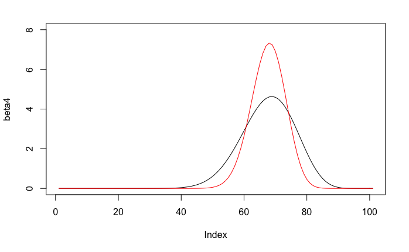

平均は同じ

```r
mean(rbeta(10000, a4, b4))
```

```
[1] 0.6659183
```

```r
mean(rbeta(10000, a5, b5))
```

```
[1] 0.6671515
```